# Q2

Convolution in matlab. Suppose you have a linear shift-invariant system with impulse response r = [4 2 1 0.5] Because it is LSI, the response of this system to any input vector in can be computed as a convolution.

## a)

Compute responses to the eight 8-dimensional impulse vectors, usingMATLAB’s conv function: out = conv(in, r). How do these compare to what you’d expect from output 2 the convolution formula given in class,

$$ y(n) = \sum_k r(n-k) x(k) $$

Specifically, compute the matrix that represents the linear system. What is the size, and organization of this matrix?

```
Response to impulse vector 1: [4.  2.  1.  0.5 0.  0.  0.  0.  0.  0.  0. ]
Response to impulse vector 2: [0.  4.  2.  1.  0.5 0.  0.  0.  0.  0.  0. ]
Response to impulse vector 3: [0.  0.  4.  2.  1.  0.5 0.  0.  0.  0.  0. ]
Response to impulse vector 4: [0.  0.  0.  4.  2.  1.  0.5 0.  0.  0.  0. ]
Response to impulse vector 5: [0.  0.  0.  0.  4.  2.  1.  0.5 0.  0.  0. ]
Response to impulse vector 6: [0.  0.  0.  0.  0.  4.  2.  1.  0.5 0.  0. ]
Response to impulse vector 7: [0.  0.  0.  0.  0.  0.  4.  2.  1.  0.5 0. ]
Response to impulse vector 8: [0.  0.  0.  0.  0.  0.  0.  4.  2.  1.  0.5]

Matrix representation of the LSI system:
[[4.  2.  1.  0.5 0.  0.  0.  0.  0.  0.  0. ]
 [0.  4.  2.  1.  0.5 0.  0.  0.  0.  0.  0. ]
 [0.  0.  4.  2.  1.  0.5 0.  0.  0.  0.  0. ]
 [0.  0.  0.  4.  2.  1.  0.5 0.  0.  0.  0. ]
 [0.  0.  0.  0.  4.  2.  1.  0.5 0.  0.  0. ]
 [0.  0.  0.  0.  0.  4.  2.  1.  0.5 0.  0. ]
 [0.  0.  0.  0.  0.  0.  4.  2.  1.  0.5 0. ]
 [0.  0.  0.  0.  0.  0.  0.  4.  2.  1.  0.5]]
```

## b)

When MATLAB's conv function convolves two signals, it does extend their lengths by padding with zeros.

For example, given two signals:

a = [1, 2, 3] b = [0.5, 1.5]

When we convolve them, it gonna extended like this:

a = [0, 1, 2, 3, 0] b = [0, 0.5, 1.5, 0, 0]

The output of the convolution will be = length(a) + length(b) - 1 = 3 + 2 - 1 = 4

```
result  = [0.5 2.5 4.5 4.5]
```

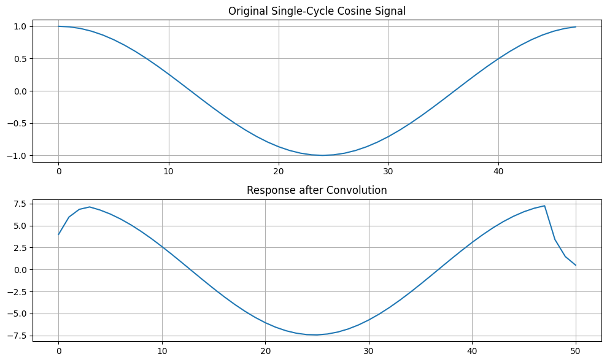

```
Length of the response: 51
```

Is this a single-cycle sinusoid? Why or why not?

This is because the impulse response is a 4-point signal, and the convolution of the original signal with the impulse response is equivalent to the sum of 4 shifted copies of the original signal.

If not, what modification is necessary to the conv function to ensure that it will behave according to the “sinein, sine-out” behavior we expect of LSI systems?

To get "sine-in, sine-out" behavior, the impulse response should be a delta function. In other words, the impulse response should be a single 1 followed by zeros. This will result in a convolution that is equivalent to the original signal.